# Honda et al. (unsubmitted): Caco-2 Data Organization and Analysis

Greg Honda and John Wambaugh

August 21, 2023

wambaugh.john@epa.gov

This vignette loads and processes the *in vitro*-measured Caco-2 membrane permeability data and creates several summary plots for both reference chemicals and newly-measured chemicals.

## Overall Manuscript Abstract

Administered equivalent dose (AED) estimation using *in vitro* hazard and high throughput toxicokinetics (HTTK) can be improved by refining assumptions regarding fraction absorbed ($F_{abs}$) through the intestine, a component of oral bioavailability ($F_{bio}$). Although *in vivo* data to inform $F_{abs}$ are often unavailable for non-pharmaceuticals, *in vitro* measures of apparent permeability ($P_{app}$) using the Caco-2 cell line have been highly correlated with $F_{abs}$ when used in *in vitro-in vivo* extrapolation (IVIVE) modeling. To address data gaps for non-drug chemicals, bidirectional $P_{app}$ was evaluated using the Caco-2 assay for over 400 chemicals. A random forest quantitative structure-property relationship (QSPR) model was developed using these and peer-reviewed pharmaceutical data. Both Caco-2 data ($R^2$=0.37) and the QSPR model ($R^2$=0.3) were better at predicting human bioavailability compared to *in vivo* rat data ($R^2$=0.2). The httk-predicted plasma steady state concentrations ($C_{ss}$) for IVIVE were updated, leading to modest changes for poorly absorbed chemicals. Experimental data were evaluated for sources of measurement uncertainty, which was then accounted for using the Monte Carlo method. Revised AEDs were subsequently compared with exposure estimates to evaluate influence on bioactivity:exposure ratios as a surrogate for risk. Ultimately, $P_{app}$ incorporation to adjust for $F_{bio}$ in httk modeling improves AED estimations used in HT risk prioritization.

## Prepare for session

### Clear memory

```r
# Delete all objects from memory:
rm(list=ls())
```

### Set the figure size

```r
loc.wd <- "C:/Users/jwambaug/git/comptox-caco2/Honda_Caco2"
knitr::opts_chunk$set(echo = TRUE, fig.width=5, fig.height=4)
knitr::opts_knit$set(root.dir = loc.wd)
```

### Load the relevant libraries

```r
packages <- c("ggplot2", "readxl", "data.table", "dplyr",
              "scales", "ggpubr", "xlsx", "viridis")
sapply(packages, require,character.only=TRUE) #Note, the "character.only" argument is necessary her
```

```
##    ggplot2     readxl data.table      dplyr     scales     ggpubr       xlsx
##       TRUE       TRUE       TRUE       TRUE       TRUE       TRUE       TRUE
##    viridis
##       TRUE
```

# Function for labeling on log-scale:

```r
scientific_10 <- function(x) {
  out <- gsub("1e", "10^", scientific_format()(x))
  out <- gsub("\\+","",out)
  out <- gsub("10\\^01","10",out)
  out <- parse(text=gsub("10\\^00","1",out))
}
```

### Plot Configuration

Here we set standard aspects of all plots, like font size.

```r
gtheme <- theme(axis.title = element_text(size=12,color="black",face="bold"),
                axis.text.y = element_text(size=10, color = "black",face="bold"),
                legend.text = element_text(size = 10),
                legend.title = element_text(size = 10),
                legend.key.size = unit(10, "points"),
                panel.background = element_rect(fill="white"),
                axis.line = element_line(color="black"),
                axis.ticks.y = element_line(color="black"),
                legend.position = "top",
                axis.line.x=element_line(color="black"),
                axis.ticks.x=element_line(color="black"),
                axis.text.x = element_text(size = 10,face="bold",color="black"),
                plot.title = element_text(hjust=0,size=12,face="bold"))
```

```r
source(paste0(loc.wd,"/r_scripts/Honda_caco2_utilities.R"))
#source('C:/Users/GHONDA/Documents/HTTKOralRoute/gh_ionization_functions.R')
#source("C:/Users/GHONDA/Documents/R homebrew/chemprop_connect/query_dsstox.measchemprop.R")
#source(paste0(loc.wd,"/r_scripts/rf_train.R"))
#source(paste0(loc.wd,"/r_scripts/Honda_caco2_fullmodel.R"))
```

### Data Processing Functions

We calculate both with and without recovery filters (low_rec_co and high_rec_co)

```r
load_caco_dt <- function(low_rec_co, high_rec_co)
{
  load(paste0(loc.wd,"/r_data/caco2_qc/caco2dt_processed.RData"))
  caco2.QC <- fread(paste0(loc.wd,"/r_data/caco2_qc/caco2dt_line101_short.csv"))
  caco2.QC[,1] <- NULL

  caco2.dt <- caco2.QC[caco2.dt,on=.(test_article,dtxsid,task_order,file_id)]
  caco2.dt <- copy(caco2.dt)
  caco2.dt[, comment_ab3 := as.character(comment_ab3)] %>%
    .[!is.na(update_Pab1),Pab1:=update_Pab1] %>%
    .[!is.na(update_Pab2),Pab2:=update_Pab2] %>%
    .[!is.na(update_Pab3),Pab3:=update_Pab3] %>%
    .[!is.na(update_rec_ab1),rec_ab1:=update_rec_ab1] %>%
    .[!is.na(update_rec_ab2),rec_ab2:=update_rec_ab2] %>%
    .[!is.na(update_rec_ab3),rec_ab3:=update_rec_ab3] %>%
    .[!is.na(update_Pba1),Pba1:=update_Pba1] %>%
    .[!is.na(update_Pba2),Pba2:=update_Pba2] %>%
    .[!is.na(update_Pba3),Pba3:=update_Pba3] %>%
    .[!is.na(update_rec_ba1),rec_ba1:=update_rec_ba1] %>%
    .[!is.na(update_rec_ba2),rec_ba2:=update_rec_ba2] %>%
    .[!is.na(update_rec_ba3),rec_ba3:=update_rec_ba3] %>%
    .[comment_ab1=="",comment_ab1:=NA_character_] %>%
    .[comment_ab2=="",comment_ab2:=NA_character_] %>%
    .[comment_ab3=="",comment_ab3:=NA_character_] %>%
    .[is.na(comment_ab1) & Pab1_orig=="ND",comment_ab1:="ND"] %>%
    .[is.na(comment_ab2) & Pab2_orig=="ND",comment_ab2:="ND"] %>%
    .[is.na(comment_ab3) & Pab3_orig=="ND",comment_ab3:="ND"] %>%
    .[comment_ba1=="",comment_ba1:=NA_character_] %>%
    .[comment_ba2=="",comment_ba2:=NA_character_] %>%
    .[comment_ba3=="",comment_ba3:=NA_character_] %>%
    .[is.na(comment_ba1) & Pba1_orig=="ND",comment_ba1:="ND"] %>%
    .[is.na(comment_ba2) & Pba2_orig=="ND",comment_ba2:="ND"] %>%
    .[is.na(comment_ba3) & Pba3_orig=="ND",comment_ba3:="ND"] %>%
# Filtering of negative Pab:
    .[Pab1 <= 0, comment_ab1:="ND"] %>%
    .[Pab2 <= 0, comment_ab2:="ND"] %>%
    .[Pab3 <= 0, comment_ab3:="ND"] %>%
    .[Pba1 <= 0, comment_ba1:="ND"] %>%
    .[Pba2 <= 0, comment_ba2:="ND"] %>%
    .[Pba3 <= 0, comment_ba3:="ND"] %>%
    .[Pab1 <= 0, Pab1:=NA_real_] %>%
    .[Pab2 <= 0, Pab2:=NA_real_] %>%
    .[Pab3 <= 0, Pab3:=NA_real_] %>%
    .[Pba1 <= 0, Pba1:=NA_real_] %>%
    .[Pba2 <= 0, Pba2:= NA_real_] %>%
    .[Pba3 <= 0, Pba3:= NA_real_] %>%
# Filtering based on low and high recovery thresholds:
    .[!(is.na(comment_ab1)|comment_ab1 %in% c("LOD","low_rec")),Pab1:=as.numeric(NA)] %>%
    .[is.na(rec_ab1) | rec_ab1 < low_rec_co | rec_ab1 > high_rec_co, Pab1:=as.numeric(NA)] %>%
    .[is.na(comment_ab1) & rec_ab1 < low_rec_co, comment_ab1:="low_rec"] %>%
    .[is.na(comment_ab1) & rec_ab1 > high_rec_co, comment_ab1:="high_rec"] %>%
    .[!(is.na(comment_ab2)|comment_ab2 %in% c("LOD","low_rec")),Pab2:=as.numeric(NA)] %>%
    .[is.na(rec_ab2) | rec_ab2 < low_rec_co | rec_ab2 > high_rec_co, Pab2:=as.numeric(NA)] %>%
    .[is.na(comment_ab2) & rec_ab2 < low_rec_co, comment_ab2:="low_rec"] %>%
    .[is.na(comment_ab2) & rec_ab2 > high_rec_co, comment_ab2:="high_rec"] %>%
    .[!(is.na(comment_ab3)|comment_ab3 %in% c("LOD","low_rec")),Pab3:=as.numeric(NA)] %>%
    .[is.na(rec_ab3) | rec_ab3 < low_rec_co | rec_ab3 > high_rec_co, Pab3:=as.numeric(NA)] %>%
    .[is.na(comment_ab3) & rec_ab3 < low_rec_co, comment_ab3:="low_rec"] %>%
    .[is.na(comment_ab3) & rec_ab3 > high_rec_co, comment_ab3:="high_rec"] %>%
    .[!(is.na(comment_ba1)|comment_ba1 %in% c("LOD","low_rec")),Pba1:=as.numeric(NA)] %>%
    .[is.na(rec_ba1) | rec_ba1 < low_rec_co | rec_ba1 > high_rec_co, Pba1:=as.numeric(NA)] %>%
    .[is.na(comment_ba1) & rec_ba1 < low_rec_co, comment_ba1:="low_rec"] %>%
    .[is.na(comment_ba1) & rec_ba1 > high_rec_co, comment_ba1:="high_rec"] %>%
    .[!(is.na(comment_ba2)|comment_ba2 %in% c("LOD","low_rec")),Pba2:=as.numeric(NA)] %>%
    .[is.na(rec_ba2) | rec_ba2 < low_rec_co | rec_ba2 > high_rec_co, Pba2:=as.numeric(NA)] %>%
    .[is.na(comment_ba2) & rec_ba2 < low_rec_co, comment_ba2:="low_rec"] %>%
    .[is.na(comment_ba2) & rec_ba2 > high_rec_co, comment_ba2:="high_rec"] %>%
    .[!(is.na(comment_ba3)|comment_ba3 %in% c("LOD","low_rec")),Pba3:=as.numeric(NA)] %>%
    .[is.na(rec_ba3) | rec_ba3 < low_rec_co | rec_ba3 > high_rec_co, Pba3:=as.numeric(NA)] %>%
    .[is.na(comment_ba3) & rec_ba3 < low_rec_co, comment_ba3:="low_rec"] %>%
    .[is.na(comment_ba3) & rec_ba3 > high_rec_co, comment_ba3:="high_rec"]
# Synthesize values across measuremnt replicates (experiment performed in triplicate:
  caco2.dt[!(is.na(rec_ab1)&is.na(rec_ab2)&is.na(rec_ab3)),
           rec_ab:=mean(c(rec_ab1,rec_ab2,rec_ab3)[!is.na(c(rec_ab1,rec_ab2,rec_ab3)) &
                                                     (c(rec_ab1,rec_ab2,rec_ab3) >= low_rec_co) &
                                                     (c(rec_ab1,rec_ab2,rec_ab3) <= high_rec_co)],na.rm=T),.(rec_ab1,rec_ab2,rec_ab3)] %>%
    .[!(is.na(rec_ab1)&is.na(rec_ab2)&is.na(rec_ab3)),
      sd_rec_ab:=sd(c(rec_ab1,rec_ab2,rec_ab3)[!is.na(c(rec_ab1,rec_ab2,rec_ab3)) &
                                                 (c(rec_ab1,rec_ab2,rec_ab3) >= low_rec_co) &
                                                 (c(rec_ab1,rec_ab2,rec_ab3) <= high_rec_co)],na.rm=T),.(rec_ab1,rec_ab2,rec_ab3)] %>%
    .[!(is.na(rec_ba1)&is.na(rec_ba2)&is.na(rec_ba3)),
      rec_ba:=mean(c(rec_ba1,rec_ba2,rec_ba3)[!is.na(c(rec_ba1,rec_ba2,rec_ba3)) &
                                                (c(rec_ba1,rec_ba2,rec_ba3) >= low_rec_co) &
                                                (c(rec_ba1,rec_ba2,rec_ba3) <= high_rec_co)],na.rm=T),.(rec_ba1,rec_ba2,rec_ba3)] %>%
    .[!(is.na(rec_ba1)&is.na(rec_ba2)&is.na(rec_ba3)),
      sd_rec_ba:=sd(c(rec_ba1,rec_ba2,rec_ba3)[!is.na(c(rec_ba1,rec_ba2,rec_ba3)) &
                                                 (c(rec_ba1,rec_ba2,rec_ba3) >= low_rec_co) &
                                                 (c(rec_ba1,rec_ba2,rec_ba3) <= high_rec_co)],na.rm=T),.(rec_ba1,rec_ba2,rec_ba3)] %>%
    .[!(is.na(Pab1)&is.na(Pab2)&is.na(Pab3)) & !(is.na(rec_ab1)&is.na(rec_ab2)&is.na(rec_ab3)),
      Pab_c:=mean(c(Pab1,Pab2,Pab3)[!is.na(c(rec_ab1,rec_ab2,rec_ab3)) &
                                      (c(rec_ab1,rec_ab2,rec_ab3) >= low_rec_co) &
                                      (c(rec_ab1,rec_ab2,rec_ab3) <= high_rec_co)],na.rm = T),.(Pab1,Pab2,Pab3)] %>%
    .[!(is.na(Pab1)&is.na(Pab2)&is.na(Pab3)) & !(is.na(rec_ab1)&is.na(rec_ab2)&is.na(rec_ab3)),
      sd_Pab:=sd(c(Pab1,Pab2,Pab3)[!is.na(c(rec_ab1,rec_ab2,rec_ab3)) &
                                     (c(rec_ab1,rec_ab2,rec_ab3) >= low_rec_co) &
                                     (c(rec_ab1,rec_ab2,rec_ab3) <= high_rec_co)],na.rm=T),.(Pab1,Pab2,Pab3)] %>%
    .[!(is.na(Pba1)&is.na(Pba2)&is.na(Pba3)) & !(is.na(rec_ba1)&is.na(rec_ba2)&is.na(rec_ba3)),
      Pba_c:=mean(c(Pba1,Pba2,Pba3)[!is.na(c(rec_ba1,rec_ba2,rec_ba3)) &
                                      (c(rec_ba1,rec_ba2,rec_ba3) >= low_rec_co) &
                                      (c(rec_ba1,rec_ba2,rec_ba3) <= high_rec_co)],na.rm=T),.(Pba1,Pba2,Pba3)] %>%
    .[!(is.na(Pba1)&is.na(Pba2)&is.na(Pba3)) & !(is.na(rec_ba1)&is.na(rec_ba2)&is.na(rec_ba3)),
      sd_Pba := sd(c(Pba1,Pba2,Pba3)[!is.na(c(rec_ba1,rec_ba2,rec_ba3)) &
                                       (c(rec_ba1,rec_ba2,rec_ba3) >= low_rec_co) &
                                       (c(rec_ba1,rec_ba2,rec_ba3) <= high_rec_co)],na.rm=T),.(Pba1,Pba2,Pba3)]

   caco2.dt[,Pab:=Pab_c] %>%
    .[,Pba:=Pba_c]
  caco2.dt[,batch_id:=batch_guess]
  caco2.dt[casrn=="106-47-8",compound:="4-Chloroaniline"] %>%
    .[casrn=="33228-44-3",compound:="4-Pentylaniline"]
  caco2.dt[casrn == "66357-35-5", c("compound", "dtxsid") := list("Ranitidine", "DTXSID8045191")] %>%
    .[casrn == "57460-41-0", c("compound", "dtxsid") := list("Talinolol", "DTXSID6046426")] %>%
    .[casrn == "81-81-2", c("compound", "dtxsid") := list("Warfarin", "DTXSID5023742")]

  caco2.dt[rec_ab < 0, rec_ab := NA_real_] %>%
    .[rec_ba < 0, rec_ba := NA_real_]

  return(caco2.dt)
}
```

# Function to apply Frec adjustment

```r
adjust_for_frec <- function(caco2.dt, Pab.thresh)
{
  caco2.dt[, Pab0 := Pab] %>%
    .[, Pba0 := Pba] %>%
    .[Pab>Pab.thresh, Pab := Pab/rec_ab] %>%
    .[Pba>Pab.thresh, Pba := Pba/rec_ba] %>%
    .[, efflux0 := Pba0/Pab0] %>%
    .[, efflux.ratio := Pba/Pab]

  return (caco2.dt)
}
```

```r
merge_chemical_replicates <- function(caco2.dt)
{
# Calculate per chemical stats:
  caco2.perchem <- caco2.dt[,
                            .(mPab = 10^mean(log10(Pab), na.rm = T),
                              sdPab = sd(log10(Pab), na.rm = T),
                              mPba = 10^mean(log10(Pba), na.rm = T),
                              sdPba = sd(log10(Pba), na.rm = T),
                              mPab0 = 10^mean(log10(Pab0), na.rm = T),
                              sdPab0 = sd(log10(Pab0), na.rm = T),
                              mPba0 = 10^mean(log10(Pba0), na.rm = T),
                              sdPba0 = sd(log10(Pba0), na.rm = T),
                              mefflux = mean(efflux.ratio, na.rm = T),
                              sdefflux = sd(efflux.ratio, na.rm = T),
                              mefflux0 = mean(efflux0, na.rm = T),
                              sdefflux0 = sd(efflux0, na.rm = T),
                              mrec_ab = mean(rec_ab, na.rm = T),
                              mrec_ba = mean(rec_ba, na.rm = T),
                              sdrec_ab = sd(rec_ab, na.rm = T),
                              sdrec_ba = sd(rec_ba, na.rm = T),
                              ntotal_recab = sum(!is.na(rec_ab)),
                              ntotal_recba = sum(!is.na(rec_ba)),
                              ntotal = .N,
                              ntotal_ab = sum(!is.na(Pab)),
                              ntotal_ba = sum(!is.na(Pba)),
                              ntotal_efflux = sum(!is.na(log10(efflux.ratio))),
                              ntotal_rab = sum(!is.na(rec_ab)),
                              ntotal_rba = sum(!is.na(rec_ba))),
                            .(casrn, dtxsid, compound)]
  caco2.perchem <- caco2.perchem[,cvPab := sdPab/mPab]
  caco2.perchem <- caco2.perchem[,cvPab0 := sdPab0/mPab0]

  return(caco2.perchem)
}
```

## ANALYSIS

### Set thresholds for low and high fractional recovery:

```r
low_rec_co <- 0.4
high_rec_co <- 2
```

#Load raw (unfiltered) data and calculate means across replicates without filtering:

```r
# No cutoffs:
  caco2.unfilt <- load_caco_dt(low_rec_co=-Inf,
                               high_rec_co=Inf)
# No adjustment:
  caco2.unfilt <- adjust_for_frec(caco2.unfilt,Pab.thresh=Inf)
  caco2.perchemraw <- merge_chemical_replicates(caco2.unfilt)
  save(caco2.perchemraw,
       file = paste0(loc.wd,
                     "/results_for_paper/RawCaco2Data.RData"))
```

```r
  caco2.dup <- caco2.unfilt
  caco2.dup[!is.na(Pab),nrep_pab := .N,.(casrn)]
  caco2.dup <- caco2.dup[nrep_pab >= 2,] %>%
    .[,mPab := mean(Pab, na.rm=TRUE), .(casrn)]
  caco2.dup <- unique(caco2.dup[,.(mPab,casrn)])[,
                 .(chemrank = rank(mPab),casrn)][caco2.dup, on = "casrn"]
```

# duplicate measures

```r
  txt.dt <- unique(caco2.dup[casrn %in%
    c("66357-35-5", "57460-41-0", "81-81-2"),
    .(compound, casrn, mPab)]) %>%
    .[, y := 1.5*mPab] %>%
    .[, x := 10^c(0.0025,1.5,0.25)] %>%
    .[, hjust := c(0, 1, 0)]

  predint1 <- pred_int(x0 = log10(caco2.dup$Pab),
                       y0 = log10(caco2.dup$mPab), alpha = 0.95)
```

```
## [1] "yint = 1.97*sqrt(0.0678(1 + 1/184 + (xn - 0.316)^2/220))"
```

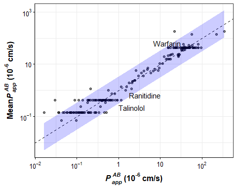

```r
  FigMeanPabvsPab <- ggplot(caco2.dup)+
    geom_point(aes(x = Pab, y = mPab), alpha = 0.5)+
    #geom_smooth(aes(x = Pab, y = mPab), method = "lm")+
    geom_abline(slope = 1, linetype = "dashed")+
    geom_ribbon(data = predint1$res.dt,
                aes(x= 10^xn, ymin = 10^yn2, ymax = 10^yn1),
                alpha = 0.2, fill = "blue")+
    geom_text(data = txt.dt,
              aes(x = x, y = y, label = compound, hjust = hjust))+
    labs(y =
           expression(bold("Mean")*bolditalic("P"["app"]^"AB")~bold('(10'^'-6'~'cm/s)')),
         x = expression(bolditalic("P"["app"]^"AB")~bold('(10'^'-6'~'cm/s)'))) +
    scale_x_log10(labels=scientific_10)+
    scale_y_log10(labels=scientific_10)+
    theme_bw() +
    gtheme

  ggsave(FigMeanPabvsPab, file = paste0(loc.wd,
    "/results_for_paper/FigMeanPabvsPab.tiff"),
    height = 3, width = 3, dpi = 600, compression = "lzw")
  print(FigMeanPabvsPab)
```

# Analysis of Raw Data

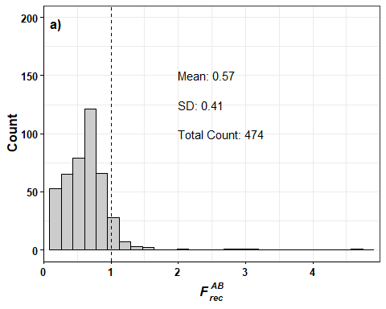

```r
  load(file = paste0(loc.wd,
                     "/results_for_paper/RawCaco2Data.RData"))

labl.dt1 <- data.table(x = 2, y = c(150, 125, 100),
                       labl = c(paste0("Mean: ", signif(mean(caco2.perchemraw[, mrec_ab], na.rm = T),2)),
                                paste0("SD: ", signif(sd(caco2.perchemraw[, mrec_ab], na.rm = T),2)),
                                paste0("Total Count: ", sum(caco2.perchemraw[, !is.na(mrec_ab) & mrec_ab > 0]))
                                ))
labl.dt2 <- data.table(x = 2, y = c(150, 125, 100),
                       labl = c(paste0("Mean: ", signif(mean(caco2.perchemraw[, mrec_ba], na.rm = T),2)),
                                paste0("SD: ", signif(sd(caco2.perchemraw[, mrec_ba], na.rm = T),2)),
                                paste0("Total Count: ", sum(caco2.perchemraw[, !is.na(mrec_ba) & mrec_ba > 0]))
                       ))

FigFrecabHist <-
  ggplot(caco2.perchemraw[mrec_ab > 0,])+
  geom_histogram(aes(x = mrec_ab), fill= "grey80", color = "black")+
  geom_vline(xintercept = 1, linetype = "dashed")+
  geom_text(data = labl.dt1, aes(x = x, y = y, label = labl), hjust = 0)+
  labs(#title = "a)",
    y = expression(bold("Count")),
    x = expression(bolditalic("F")[bolditalic("rec")]^bolditalic("AB"))) +
  #lims(x = c(0,2.1), y = c(0,85))+
  scale_x_continuous(limits = c(0, 5), breaks = c(0,1,2,3,4), expand = c(0,0))+
  scale_y_continuous(limits = c(0,200))+
  theme_bw()+
  gtheme+
  annotation_custom(grob = text_grob("a)", hjust = 0, size = 12, face = "bold"),
                    ymin = 195,ymax = 195,xmax = 0.1, xmin = 0.1)

FigFrecbaHist <-
  ggplot(caco2.perchemraw[mrec_ba > 0,])+
  geom_histogram(aes(x = mrec_ba), fill= "grey80", color = "black")+
  geom_vline(xintercept = 1, linetype = "dashed")+
  geom_text(data = labl.dt2, aes(x = x, y = y, label = labl), hjust = 0)+
  labs(#title = "Talinolol",
    y = expression(bold("Count")),
    x = expression(bolditalic("F")[bolditalic("rec")]^bolditalic("BA"))) +
  scale_x_continuous(limits = c(0, 5), breaks = c(0,1,2,3,4), expand = c(0,0))+
  scale_y_continuous(limits = c(0,200))+
  #lims(x = c(0,2.1), y = c(0,85))+
  theme_bw()+
  gtheme+
  annotation_custom(grob = text_grob("b)", hjust = 0, size = 12, face = "bold"),
                    ymin = 195,ymax = 195,xmax = 0.1, xmin = 0.1)

ggsave(FigFrecabHist, file = paste0(loc.wd, "/results_for_paper/Fig_mrec_ab_histo.tiff"),
       height = 3, width = 3, dpi = 600, compression = "lzw")
ggsave(FigFrecbaHist, file = paste0(loc.wd, "/results_for_paper/Fig_mrec_ba_histo.tiff"),
       height = 3, width = 3, dpi = 600, compression = "lzw")
print(FigFrecabHist)
```

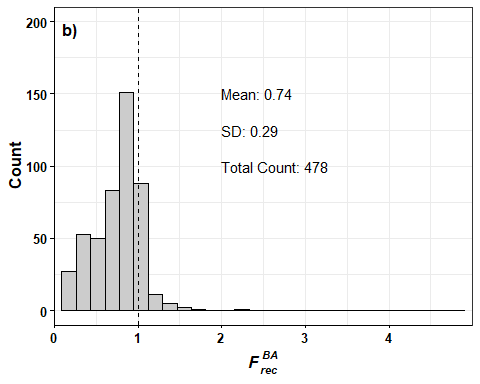

```r
print(FigFrecbaHist)
```

```r
  load(file = paste0(loc.wd,
                     "/results_for_paper/RawCaco2Data.RData"))

Num.positive.frec.ab <- length(unique(subset(caco2.perchemraw,
                                             mrec_ab > 0)$dtxsid))
Num.positive.frec.ba <- length(unique(subset(caco2.perchemraw,
                                             mrec_ba > 0)$dtxsid))
Num.chems <- length(unique(caco2.perchemraw$dtxsid))

cat(paste("The Caco-2 assay was attempted for ",
          Num.chems,
          " chemicals. Of these, ",
          Num.positive.frec.ab,
          " chemicals had a measurable PappAB (apical to basolateral) and ",
          Num.positive.frec.ba,
          " had a measurable PappBA.\n",sep=""))
```

```
## The Caco-2 assay was attempted for 484 chemicals. Of these, 474 chemicals had a measurable PappAB (apical to basolateral) and 478 had a measurable PappBA.
```

# Reload data using cutoffs based on fraction recovered (Frec):

```r
# Low and high cutoffs:
  caco2.filt <- load_caco_dt(low_rec_co=0.4,
                               high_rec_co=2)
```

```r
Num.good.Pab <- length(unique(subset(caco2.filt,
                                             !is.na(Pab))$dtxsid))
Num.good.Pba <- length(unique(subset(caco2.filt,
                                             !is.na(Pba))$dtxsid))
Num.chems.either <- length(unique(subset(caco2.filt,
                                   !is.na(Pab) |
                                             !is.na(Pba))$dtxsid))
Num.chems.both <- length(unique(subset(caco2.filt,
                                   !is.na(Pab) &
                                             !is.na(Pba))$dtxsid))

cat(paste("After filtering by Frec, there were a total of ",
          Num.chems.either,
          " chemicals that had either PappAB or PappBA and ",
          Num.chems.both,
          " that had both. Of these, ",
          Num.good.Pab,
          " chemicals had usable PappAB and ",
          Num.good.Pba,
          " had a usable PappBA.\n",sep=""))
```

```
## After filtering by Frec, there were a total of 404 chemicals that had either PappAB or PappBA and 302 that had both. Of these, 310 chemicals had usable PappAB and 396 had a usable PappBA.
```

# Analysis of Filtered Data

# Stats on adjusting Pab for fraction recovered:

```r
Pab.thresh <- 10

  lmstat1 <- summary(lm(Pab ~ rec_ab, data =
                          subset(caco2.filt,Pab>Pab.thresh)))
  lmstat2 <- summary(lm(Pab/rec_ab ~ rec_ab, data =
                          subset(caco2.filt,Pab>Pab.thresh)))
  lmstat3 <- summary(lm(Pba ~ rec_ba, data =
                          subset(caco2.filt,Pba>Pab.thresh)))
  lmstat4 <- summary(lm(Pba/rec_ba ~ rec_ba, data =
                          subset(caco2.filt,Pba>Pab.thresh)))

# Create labels for figures:
  labl.dt1 <- data.table(x = 0.5,
                         y = c(120,100),
                         labl = c("p*'-'*value:~'<'~0.001",
                                  paste0("R^2: ", signif(lmstat1$r.squared,2))))
  labl.dt2 <- data.table(x = 0.5,
                         y = c(120,100),
                         labl = c(paste0("p*'-'*value: ", signif(lmstat2$coefficients[2,4],2)),
                                  paste0("R^2: ", signif(lmstat2$r.squared,2))))
  labl.dt3 <- data.table(x = 0.5,
                         y = c(120,100),
                         labl = c("p*'-'*value:~'<'~0.001",
                                  paste0("R^2: ", signif(lmstat3$r.squared,2))))
  labl.dt4 <- data.table(x = 0.5,
                         y = c(120,100),
                         labl = c(paste0("p*'-'*value: ", signif(lmstat2$coefficients[2,4],2)),
                                  paste0("R^2: ", signif(lmstat4$r.squared,2))))
```

```r
# Divide Papp values > 0 by Frec:
  caco2.filt <- adjust_for_frec(caco2.filt,
                                  Pab.thresh=0)
```

# recovery vs permeability graphs - S1

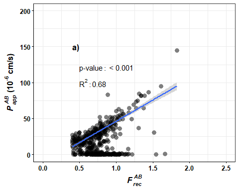

```r
  FigPabvsRecovery <- ggplot(caco2.filt) +
    geom_point(aes(x = rec_ab, y = Pab0),
               fill = "grey90", color = "black",
               size = 3, shape = 16, alpha = 0.5) +
    geom_smooth(aes(x = rec_ab, y = Pab0), data=
                      subset(caco2.filt,Pab0>Pab.thresh), method = "lm")+
    geom_text(data = labl.dt1,aes(x = x, y=y, label = labl), parse = T, hjust = 0)+
    labs(x = expression(bolditalic("F")[bolditalic("rec")]^bolditalic("AB")),
         y = expression(bolditalic("P"["app"]^"AB")~bold('(10'^'-6'~'cm/s)'))) +
    lims(x=c(0,2.5),y=c(0,200))+
    theme_bw()+
    gtheme+
    annotation_custom(grob = text_grob("a)", hjust = 0, size = 12, face = "bold"),
                      ymin = 150,ymax = 150,xmax = 0.4, xmin = 0.4)
  print(FigPabvsRecovery)
```

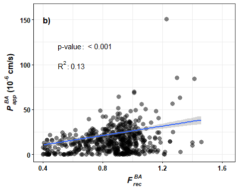

```r
  FigAdjPabvsRecovery <- ggplot(caco2.filt) +
    geom_point(aes(x = rec_ab, y = Pab),
               fill = "grey90", color = "black",
               size = 3, shape = 16, alpha = 0.5) +
    geom_smooth(aes(x = rec_ab, y = Pab), method = "lm")+
    geom_text(data = labl.dt2,aes(x = x, y=y, label = labl), parse = T, hjust = 0)+
    lims(y = c(0,150))+
    labs(x = expression(bolditalic("F")[bolditalic("rec")]^bolditalic("AB")),
         y = expression(bolditalic("P"["app"]^"AB")~bold('(10'^'-6'~'cm/s)'))) +
    theme_bw()+
    gtheme+
    annotation_custom(grob = text_grob("a)", hjust = 0, size = 12, face = "bold"),
                      ymin = 150,ymax = 150,xmax = 0.4, xmin = 0.4)

  FigPbavsRecovery <- ggplot(caco2.filt) +
    geom_point(aes(x = rec_ba, y = Pba0),
               fill = "grey90", color = "black",
               size = 3, shape = 16, alpha = 0.5) +
    geom_smooth(aes(x = rec_ba, y = Pba0), data=
                      subset(caco2.filt,Pba0>Pab.thresh), method = "lm")+
    geom_text(data = labl.dt3,aes(x = x, y=y, label = labl), parse = T, hjust = 0)+
    lims(y= c(0,160))+
    labs(x = expression(bolditalic("F")[bolditalic("rec")]^bolditalic("BA")),
         y = expression(bolditalic("P"["app"]^"BA")~bold('(10'^'-6'~'cm/s)'))) +
    theme_bw()+
    gtheme+
    annotation_custom(grob = text_grob("b)", hjust = 0, size = 12, face = "bold"),
                      ymin = 150,ymax = 150,xmax = 0.4, xmin = 0.4)
  print(FigPbavsRecovery)
```

```r
  FigAdjPbavsRecovery <- ggplot(caco2.filt) +
    geom_point(aes(x = rec_ba, y = Pba),
               fill = "grey90", color = "black",
               size = 3, shape = 16, alpha = 0.5) +
    geom_smooth(aes(x = rec_ba, y = Pba), method = "lm")+
    geom_text(data = labl.dt4,aes(x = x, y=y, label = labl), parse = T, hjust = 0)+
    lims(y = c(0,160))+
    labs(x = expression(bold("Recovery")[bolditalic("BA")]),
         y = expression(bolditalic("P"["app"]^"BA")~bold('(10'^'-6'~'cm/s)'))) +
    theme_bw()+
    gtheme+
    annotation_custom(grob = text_grob("b)", hjust = 0, size = 12, face = "bold"),
                      ymin = 150,ymax = 150,xmax = 0.4, xmin = 0.4)

  ggsave(FigPabvsRecovery, file = paste0(loc.wd, "/results_for_paper/Fig_recab_v_Pab1.tiff"),
         height = 3, width = 3, dpi = 600, compression = "lzw")
  ggsave(FigAdjPabvsRecovery, file = paste0(loc.wd, "/results_for_paper/Fig_recab_v_Pab2.tiff"),
         height = 3, width = 3, dpi = 600, compression = "lzw")
  ggsave(FigPbavsRecovery, file = paste0(loc.wd, "/results_for_paper/Fig_recba_v_Pba1.tiff"),
         height = 3, width = 3, dpi = 600, compression = "lzw")
  ggsave(FigAdjPbavsRecovery, file = paste0(loc.wd, "/results_for_paper/Fig_recba_v_Pba2.tiff"),
         height = 3, width = 3, dpi = 600, compression = "lzw")
caco2.filt[, Pab.unadj.unfilt := caco2.unfilt$Pab0] %>%
  .[, Pba.unadj.unfilt := caco2.unfilt$Pba0] %>%
  .[, efflux.unadj.unfilt := caco2.unfilt$Pba0/caco2.unfilt$Pab0] %>%
  .[, rec_ab.unfilt := caco2.unfilt$rec_ab] %>%
  .[, rec_ba.unfilt := caco2.unfilt$rec_ba]
```

```r
dim(unique(caco2.filt[,.(casrn, batch_id, t_type)]))
```

```
## [1] 639   3
```

```r
caco2.publish <- caco2.filt[,.(casrn, batch_id, t_type,
                               Pab.unadj.unfilt,
                               Pba.unadj.unfilt,
                               efflux.unadj.unfilt,
                               rec_ab.unfilt,
                               rec_ba.unfilt)][caco2.filt,
                                               on = c("casrn",
                                                      "batch_id",
                                                      "t_type")]

caco2.publish[, Pab.unadj := Pab0] %>%
  .[, Pba.unadj := Pba0] %>%
  .[, efflux.unadj := efflux0]

# Identify the results that were filtered out:
caco2.publish[,"Filtered"] <- ""
caco2.publish[!is.na(Pab.unadj.unfilt) & is.na(Pab.unadj),"Filtered"] <- "Y"

setcolorder(caco2.publish,
            c("compound","casrn","dtxsid","batch_id","t_type",
              "Pab", "Pba", "efflux.ratio", "rec_ab", "rec_ba",
              "Pab.unadj", "Pba.unadj", "efflux.unadj",
              "Pab.unadj.unfilt", "Pba.unadj.unfilt", "efflux.unadj.unfilt",
              "rec_ab.unfilt", "rec_ba.unfilt"))
caco2.publish[, casrn := paste0(" ", casrn)]
write.xlsx(caco2.publish,
           file = paste0(loc.wd, "/results_for_paper/caco2_data.xlsx"),
           showNA=FALSE)
save(caco2.publish, file = paste0(loc.wd,"/r_data/processed/our_caco2.RData"))

length(unique(caco2.publish[!is.na(casrn),casrn])) #484
```

```
## [1] 484
```

```r
caco2.all <- caco2.filt[,.(mPab = mean(Pab,na.rm = T),
                           mPba = mean(Pba, na.rm = T)),
                        .(casrn)]
caco2.all[,.N,.(is.na(mPab))] #423
```

```
##    is.na   N
## 1: FALSE 310
## 2:  TRUE 174
```

```r
caco2.all[,.N,.(is.na(mPba))] #453
```

```
##    is.na   N
## 1: FALSE 396
## 2:  TRUE  88
```

```r
length(unique(caco2.publish[!is.na(Pab), casrn])) # 310
```

```
## [1] 310
```

```r
length(unique(caco2.publish[!is.na(Pba), casrn])) # 396
```

```
## [1] 396
```

```r
length(unique(caco2.publish[!is.na(Pba) & !is.na(Pab), casrn])) # 302
```

```
## [1] 302
```

```r
# batch control pab vs upper and lower 5th percentiles - S2

  names(caco2.publish)
```

```
##  [1] "compound"              "casrn"                 "dtxsid"
##  [4] "batch_id"              "t_type"                "Pab"
##  [7] "Pba"                   "efflux.ratio"          "rec_ab"
## [10] "rec_ba"                "Pab.unadj"             "Pba.unadj"
## [13] "efflux.unadj"          "Pab.unadj.unfilt"      "Pba.unadj.unfilt"
## [16] "efflux.unadj.unfilt"   "rec_ab.unfilt"         "rec_ba.unfilt"
## [19] "comment_ab1"           "comment_ab2"           "comment_ab3"
## [22] "comment_ba1"           "comment_ba2"           "comment_ba3"
## [25] "update_Pab1"           "update_Pab2"           "update_Pab3"
## [28] "update_Pba1"           "update_Pba2"           "update_Pba3"
## [31] "update_rec_ab1"        "update_rec_ab2"        "update_rec_ab3"
## [34] "update_rec_ba1"        "update_rec_ba2"        "update_rec_ba3"
## [37] "test_article"          "task_order"            "file_id"
## [40] "Pab1"                  "Pab2"                  "Pab3"
## [43] "Pba1"                  "Pba2"                  "Pba3"
## [46] "Pab1_orig"             "Pab2_orig"             "Pab3_orig"
## [49] "Pba1_orig"             "Pba2_orig"             "Pba3_orig"
## [52] "efflux_ratio1"         "efflux_ratio2"         "efflux_ratio3"
## [55] "rec_ab1"               "rec_ab2"               "rec_ab3"
## [58] "rec_ba1"               "rec_ba2"               "rec_ba3"
## [61] "rec_ab1_orig"          "rec_ab2_orig"          "rec_ab3_orig"
## [64] "rec_ba1_orig"          "rec_ba2_orig"          "rec_ba3_orig"
## [67] "batch_guess2"          "comments"              "test_conc_uM"
## [70] "assay_duration_hr"     "efflux_ratio"          "batch_guess"
## [73] "Pab.orig"              "Pba.orig"              "efflux_ratio.orig"
## [76] "sd_rec_ab"             "sd_rec_ba"             "Pab_c"
## [79] "sd_Pab"                "Pba_c"                 "sd_Pba"
## [82] "Pab0"                  "Pba0"                  "efflux0"
## [85] "i.Pab.unadj.unfilt"    "i.Pba.unadj.unfilt"    "i.efflux.unadj.unfilt"
## [88] "i.rec_ab.unfilt"       "i.rec_ba.unfilt"       "Filtered"
```

```r
  caco2.5perc <- copy(caco2.publish)
  s2.dt <- caco2.5perc[, hcPab := Pab[casrn == "81-81-2" & t_type == "control"], .(batch_id)] %>%
    .[, lcPab := Pab[casrn == "66357-35-5" & t_type == "control"], .(batch_id)] %>%
    .[, Pab95 := quantile(Pab[t_type != "control"], 0.95, na.rm = TRUE), .(batch_id)] %>%
    .[, Pab05 := quantile(Pab[t_type != "control"], 0.05, na.rm = TRUE), .(batch_id)] %>%
    .[,.(hcPab, lcPab, Pab95, Pab05, batch_id)] %>%
    unique(.)

  FigMeanPabvsPab <- ggplot(s2.dt) +
    geom_point(aes(x = hcPab, y = Pab95),
               fill = "grey90", color = "black",
               size = 3, shape = 16, alpha = 0.5) +
    labs(x = expression(bold("Warfarin log"["10"])*bolditalic("P"["app"]^"AB")~bold('(10'^'-6'~'cm/s)')),
         y = expression(bold("95%")~bold("log"["10"])*bolditalic("P"["app"]^"AB")~bold('(10'^'-6'~'cm/s)'))) +
    theme_bw()+
    gtheme
  #print(g1)
  ggsave(FigMeanPabvsPab, file = paste0(loc.wd, "/results_for_paper/Fig_MeanPabvsPAb.tiff"),
         height = 3, width = 3, dpi = 600, compression = "lzw")
  caco2.perchem <- merge_chemical_replicates(caco2.filt)
# This table has one row per chemical:
  save(caco2.perchem,
       file = paste0(loc.wd, "/r_data/processed/MeanChemicalMeasurements.RData"))
```

```r
load(file = paste0(loc.wd, "/r_data/processed/MeanChemicalMeasurements.RData"))
cat(paste("Across the newly measured chemicals the mean Pab was ",
          signif(mean(caco2.perchem$mPab,na.rm=TRUE),2),
          " 10-6 cm/s, the median was ",
          signif(median(caco2.perchem$mPab,na.rm=TRUE),2),
          ", the min was ",
          signif(min(caco2.perchem$mPab,na.rm=TRUE),2),
          ", and the max was ",
          signif(max(caco2.perchem$mPab,na.rm=TRUE),2),
          ".\n",sep=""))
```

```
## Across the newly measured chemicals the mean Pab was 29 10-6 cm/s, the median was 32, the min was 0.00066, and the max was 94.
```

```r
  min(caco2.publish[casrn %in% "81-81-2",.(Pab,Pba,Pab0,Pba0)], na.rm = T)
```

```
## [1] Inf
```

```r
  max(caco2.publish[casrn == " 81-81-2",.(Pab,Pba,Pab0,Pba0)], na.rm = T)
```

```
## [1] 94.84593
```

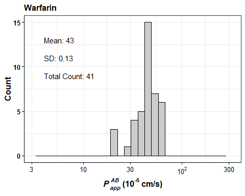

```r
  labl.FigWarfarinPabAdj <- caco2.perchem[casrn == "81-81-2",.(labl = c(
    paste0("Mean: ",signif(mPab,2)),
    paste0("SD: ", signif(sdPab,2)),
   # paste0("CV: ", signif(cvPab,2)),
    paste0("Total Count: ", ntotal_ab)),
                                                   x = 4,
                                                   y = 0+c(13,11,9#,7
                                                         ))]
  labl.FigWarfarinPabUnadj <- caco2.perchem[casrn == "81-81-2",.(labl = c(
    paste0("Mean: ",signif(mPab0,2)),
    paste0("SD: ", signif(sdPab0,2)),
   # paste0("CV: ", signif(cvPab0,2)),
    paste0("Total Count: ", ntotal_ab)),
                                                   x = 1,
                                                   y = -4+c(13,11,9#,10
                                                              ))]
  labl.FigWarfarinPbaAdjHist <- caco2.perchem[casrn == "81-81-2",.(labl = c(
    paste0("Mean: ",signif(mPba,2)),
    paste0("SD: ", signif(sdPba,2)),
    paste0("Total Count: ", ntotal_ba)),
                                                 x = 4,
                                                 y = c(8,7,6)-1)]
  labl.FigWarfarinEffluxRAdjHist <- caco2.perchem[casrn == "81-81-2",.(labl = c(
    paste0("Mean: ",signif(mefflux,2)),
    paste0("SD: ", signif(sdefflux,2)),
    paste0("Total Count: ", ntotal_efflux)),
                                                 x = 0.1,
                                                 y = c(8,7,6))]

  labl.FigWarfarinFrecabHist <- caco2.perchem[casrn == "81-81-2",.(labl = c(
    paste0("Mean: ",signif(mrec_ab,2)),
    paste0("SD: ", signif(sdrec_ab,2)),
    paste0("Total Count: ", ntotal_recab
                                                              )),
                                                     x = 1.1,
                                                     y = c(7,6,5))]
  labl.FigWarfarinFrecbaHist <- caco2.perchem[casrn == "81-81-2",.(labl = c(
    paste0("Mean: ",signif(mrec_ba,2)),
    paste0("SD: ", signif(sdrec_ba,2)),
    paste0("Total Count: ", ntotal_recba
                                                              )),
                                                     x = 1.1,
                                                     y = c(10,8,6))]
  FigWarfarinPabAdjHist <- ggplot(caco2.publish[casrn == " 81-81-2",])+
    geom_histogram(aes(x = Pab), fill= "grey80", color = "black")+
    geom_text(data = labl.FigWarfarinPabAdj,
              aes(x = x, y= y, label = labl), hjust = 0)+
    labs(title = "Warfarin",
         y = expression(bold("Count")),
         x = expression(bolditalic("P"["app"]^"AB")~bold('(10'^'-6'~'cm/s)'))) +
    scale_x_log10(labels=scientific_10,limits=c(10^0.5,10^2.5))+
    scale_y_continuous(breaks = c(0, 5, 10, 15))+
    theme_bw()+
    gtheme
  print(FigWarfarinPabAdjHist)
```

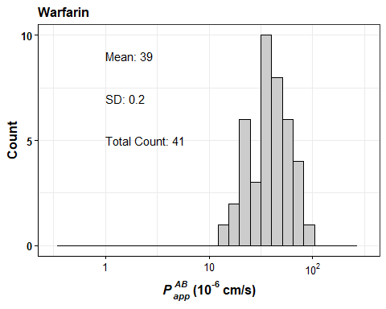

```r
  FigWarfarinPabUnadjHist <- ggplot(caco2.publish[casrn == " 81-81-2",])+
    geom_histogram(aes(x = Pab0), fill= "grey80", color = "black")+
    geom_text(data = labl.FigWarfarinPabUnadj,
              aes(x = x, y= y, label = labl), hjust = 0)+
    labs(title = "Warfarin",
         y = expression(bold("Count")),
         x = expression(bolditalic("P"["app"]^"AB")~bold('(10'^'-6'~'cm/s)'))) +
    scale_x_log10(labels=scientific_10,limits=c(10^-0.5,10^2.5))+
    scale_y_continuous(breaks = c(0,5,10), limits = c(0,10))+
    theme_bw()+
    gtheme
  print(FigWarfarinPabUnadjHist)
```

```r
  FigWarfarinPbaAdjHist <- ggplot(caco2.publish[casrn == " 81-81-2",])+
    geom_histogram(aes(x = Pba), fill= "grey80", color = "black")+
    geom_text(data = labl.FigWarfarinPbaAdjHist,aes(x = x, y= y, label = labl), hjust = 0)+
    labs(title = "Warfarin",
         y = expression(bold("Count")),
         x = expression(bolditalic("P"["app"]^"BA")~bold('(10'^'-6'~'cm/s)'))) +
    scale_x_log10(labels=scientific_10,limits=c(10^0.5,10^1.75))+
    theme_bw()+
    gtheme
  #print(g3b)

  FigWarfarinPbaUnadjHist <- ggplot(caco2.publish[casrn == " 81-81-2",])+
    geom_histogram(aes(x = Pba0), fill= "grey80", color = "black")+
    labs(title = "Warfarin",
         y = expression(bold("Count")),
         x = expression(bolditalic("P"["app"]^"BA")~bold('(10'^'-6'~'cm/s)'))) +
    lims(y = c(0, 12))+
    scale_x_log10(labels=scientific_10,limits=c(10^-0.5,10^2.5))+
    theme_bw()+
    gtheme

  FigWarfarinEffluxRAdjHist <- ggplot(caco2.publish[casrn == " 81-81-2",])+
    geom_histogram(aes(x = efflux.ratio), fill= "grey80", color = "black")+
    geom_text(data = labl.FigWarfarinEffluxRAdjHist, aes(x = x, y= y, label = labl), hjust = 0)+
    labs(title = "Warfarin",
         y = expression(bold("Count")),
         x = expression(bold("Efflux Ratio"))) +
    #lims(x = c(0.75,2.25))+
    scale_x_log10(labels=scientific_10)+
    theme_bw()+
    gtheme

  FigWarfarinEffluxRUnadjHist <- ggplot(caco2.publish[casrn == " 81-81-2",])+
    geom_histogram(aes(x =efflux0), fill= "grey80", color = "black")+
    labs(title = "Warfarin",
         y = expression(bold("Count")),
         x = expression(bold("Efflux Ratio"))) +
    #lims(x = c(0.75,2.25))+
    scale_x_log10(labels=scientific_10)+
    theme_bw()+
    gtheme

  FigWarfarinFrecabHist <-
    ggplot(caco2.publish[casrn == " 81-81-2",])+
    geom_histogram(aes(x = rec_ab), fill= "grey80", color = "black")+
    geom_text(data = labl.FigWarfarinFrecabHist,
              aes(x = x, y= y, label = labl), hjust = 0)+
    labs(title = "Warfarin",
         y = expression(bold("Count")),
         x = expression(bolditalic("F")[bolditalic("rec")]^bolditalic("AB"))) +
    lims(x = c(0,2.2))+
    theme_bw()+
    gtheme

  FigWarfarinFrecbaHist <-
    ggplot(caco2.publish[casrn == " 81-81-2",])+
    geom_histogram(aes(x = rec_ba), fill= "grey80", color = "black")+
    geom_text(data = labl.FigWarfarinFrecbaHist, aes(x = x, y= y, label = labl), hjust = 0)+
    labs(title = "Warfarin",
         y = expression(bold("Count")),
         x = expression(bolditalic("F")[bolditalic("rec")]^bolditalic("BA"))) +
    lims(x = c(0,2.2))+
    theme_bw()+
    gtheme

  ggsave(FigWarfarinPabAdjHist, file = paste0(loc.wd,
    "/results_for_paper/Fig_warfarin_Pab_histo.tiff"),
         height = 3, width = 3, dpi = 600, compression = "lzw")
  ggsave(FigWarfarinPbaAdjHist, file = paste0(loc.wd,
    "/results_for_paper/Fig_warfarin_Pba_histo.tiff"),
         height = 3, width = 3, dpi = 600, compression = "lzw")
  ggsave(FigWarfarinEffluxRAdjHist, file = paste0(loc.wd,
    "/results_for_paper/Fig_warfarin_efflux_histo.tiff"),
         height = 3, width = 3, dpi = 600, compression = "lzw")
  ggsave(FigWarfarinFrecabHist, file = paste0(loc.wd,
    "/results_for_paper/Fig_warfarin_recab_histo.tiff"),
         height = 3, width = 3, dpi = 600, compression = "lzw")
  ggsave(FigWarfarinFrecbaHist, file = paste0(loc.wd,
    "/results_for_paper/Fig_warfarin_recba_histo.tiff"),
         height = 3, width = 3, dpi = 600, compression = "lzw")
  ggsave(FigWarfarinPabUnadjHist, file = paste0(loc.wd,
    "/results_for_paper/Fig_warfarin_Pab0_histo.tiff"),
    height = 3, width = 3, dpi = 600, compression = "lzw")
  # ggsave(g4b, file = paste0(loc.wd, "/results_for_paper/warfarin_Pba0_histo.tiff"),
  #        height = 3, width = 3, dpi = 600, compression = "lzw")
  # ggsave(g4c, file = paste0(loc.wd, "/results_for_paper/warfarin_efflux0_histo.tiff"),
  #        height = 3, width = 3, dpi = 600, compression = "lzw")
```

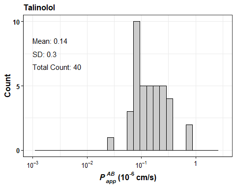

```r
  labl.dtFigTalinololPabAdj <- caco2.perchem[casrn == "57460-41-0",.(labl = c(
    paste0("Mean: ",signif(mPab,2)),
    paste0("SD: ", signif(sdPab,2)),
    #paste0("CV: ", signif(cvPab,2)),
    paste0("Total Count: ", ntotal_ab)),
                                                   x = 0.001,
                                                   y = -1+c(9.5,8.5,7.5#,6.5
                                                         ))]
  labl.dtFigTalinololPabUnadj <- caco2.perchem[casrn == "57460-41-0",.(labl = c(
    paste0("Mean: ",signif(mPab0,2)),
    paste0("SD: ", signif(sdPab0,2)),
   # paste0("CV: ", signif(cvPab0,2)),
    paste0("Total Count: ", ntotal_ab)),
                                                   x = 0.001,
                                                   y = -1+c(9.5,8.5,7.5#,6.5
                                                         ))]
  labl.FigTalinololPbaAdjHist <- caco2.perchem[casrn == "57460-41-0",.(labl = c(
    paste0("Mean: ",signif(mPba,2)),
    paste0("SD: ", signif(sdPba,2)),
    paste0("Total Count: ", ntotal_ba)),
                                                    x = 0.1,
                                                    y = c(7.5,6.5,5.5))]
  labl.FigTalinololEffluxRAdjHist <- caco2.perchem[casrn == "57460-41-0",.(labl = c(
    paste0("Mean: ",signif(mefflux,2)),
    paste0("SD: ", signif(sdefflux,2)),
    paste0("Total Count: ", ntotal_efflux)),
                                                    x = 1,
                                                    y = -2+c(7.5,6.5,5.5))]

  labl.FigTalinololFrecabHist <- caco2.perchem[casrn == "57460-41-0",.(labl = c(
    paste0("Mean: ",signif(mrec_ab,2)),
    paste0("SD: ", signif(sdrec_ab,2)),
    paste0("Total Count: ", ntotal_recab
                                                              )),
                                                     x = 1.1,
                                                     y = c(10,8,6))]
  labl.FigTalinololFrecbaHist <- caco2.perchem[casrn == "57460-41-0",.(labl = c(
    paste0("Mean: ",signif(mrec_ba,2)),
    paste0("SD: ", signif(sdrec_ba,2)),
    paste0("Total Count: ", ntotal_recba
                                                              )),
                                                     x = 1.1,
                                                     y = c(10,8,6))]

  FigTalinololPabAdjHist <- ggplot(caco2.publish[casrn == " 57460-41-0",])+
    geom_histogram(aes(x = Pab), fill= "grey80", color = "black")+
    geom_text(data = labl.dtFigTalinololPabAdj,
              aes(x = x, y= y, label = labl), hjust = 0)+
    labs(title = "Talinolol",
         y = expression(bold("Count")),
         x = expression(bolditalic("P"["app"]^"AB")~bold('(10'^'-6'~'cm/s)'))) +
    scale_y_continuous(breaks = c(0,5,10), limits = c(0,10))+
    scale_x_log10(labels=scientific_10,limits=c(10^-3,10^0.5))+
    theme_bw()+
    gtheme
  print(FigTalinololPabAdjHist)
```

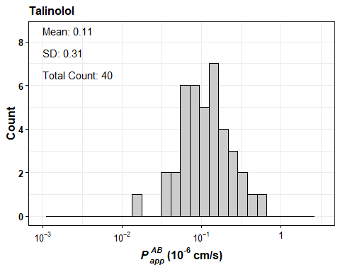

```r
  FigTalinololPabUnadjHist <- ggplot(caco2.publish[casrn == " 57460-41-0",])+
    geom_histogram(aes(x = Pab0), fill= "grey80", color = "black")+
    geom_text(data = labl.dtFigTalinololPabUnadj,
              aes(x = x, y= y, label = labl), hjust = 0)+
    labs(title = "Talinolol",
         y = expression(bold("Count")),
         x = expression(bolditalic("P"["app"]^"AB")~bold('(10'^'-6'~'cm/s)'))) +
    lims(x = c(-2.5,0.5))+
    scale_x_log10(labels=scientific_10,limits=c(10^-3,10^0.5))+
    theme_bw()+
    gtheme
  print(FigTalinololPabUnadjHist)
```

```r
  FigTalinololPbaAdjHist <- ggplot(caco2.publish[casrn == " 57460-41-0",])+
    geom_histogram(aes(x = Pba), fill= "grey80", color = "black")+
    geom_text(data = labl.FigTalinololPbaAdjHist, aes(x = x, y= y, label = labl), hjust = 0)+
    labs(title = "Talinolol",
         y = expression(bold("Count")),
         x = expression(bolditalic("P"["app"]^"BA")~bold('(10'^'-6'~'cm/s)'))) +
    scale_x_log10(labels=scientific_10,limits=c(10^-1,10^2.5))+
    theme_bw()+
    gtheme

  FigTalinololPbaUnadjHist  <- ggplot(caco2.publish[casrn == " 57460-41-0",])+
    geom_histogram(aes(x = Pba0), fill= "grey80", color = "black")+
    labs(title = "Talinolol",
         y = expression(bold("Count")),
         x = expression(bolditalic("P"["app"]^"BA")~bold('(10'^'-6'~'cm/s)'))) +
    scale_x_log10(labels=scientific_10,limits=c(10^-1,10^2.5))+
    theme_bw()+
    gtheme

  FigTalinololEffluxRAdjHist <- ggplot(caco2.publish[casrn == " 57460-41-0",])+
    geom_histogram(aes(x = efflux.ratio), fill= "grey80", color = "black")+
    geom_text(data = labl.FigTalinololEffluxRAdjHist,
              aes(x = x, y= y, label = labl), hjust = 0)+
    labs(title = "Talinolol",
         y = expression(bold("Count")),
         x = expression(bold("Efflux Ratio"))) +
    #lims(x = c(0.75,2.25))+
    scale_x_log10(labels=scientific_10)+
    theme_bw()+
    gtheme

  FigTalinololEffluxRUnadjHist <- ggplot(caco2.publish[casrn == " 57460-41-0",])+
    geom_histogram(aes(x = efflux0), fill= "grey80", color = "black")+
    labs(title = "Talinolol",
         y = expression(bold("Count")),
         x = expression(bold("Efflux Ratio"))) +
    #lims(x = c(0.75,2.25))+
    scale_x_log10(labels=scientific_10)+
    theme_bw()+
    gtheme

  FigTalinololFrecabHist <-
    ggplot(caco2.publish[casrn == " 57460-41-0",])+
    geom_histogram(aes(x = rec_ab), fill= "grey80", color = "black")+
    geom_text(data = labl.FigTalinololFrecabHist,
              aes(x = x, y= y, label = labl), hjust = 0)+
    labs(title = "Talinolol",
         y = expression(bold("Count")),
         x = expression(bolditalic("F")[bolditalic("rec")]^bolditalic("AB"))) +
    lims(x = c(0,2.2))+
    theme_bw()+
    gtheme

  FigTalinololFrecbaHist <-
    ggplot(caco2.publish[casrn == " 57460-41-0",])+
    geom_histogram(aes(x = rec_ba), fill= "grey80", color = "black")+
    geom_text(data = labl.FigTalinololFrecbaHist,
              aes(x = x, y= y, label = labl), hjust = 0)+
    labs(title = "Talinolol",
         y = expression(bold("Count")),
         x = expression(bolditalic("F")[bolditalic("rec")]^bolditalic("BA"))) +
    lims(x = c(0,2.2))+
    theme_bw()+
    gtheme

  ggsave(FigTalinololPabAdjHist, file = paste0(loc.wd,
    "/results_for_paper/Fig_Talinolol_Pab_histo.tiff"),
         height = 3, width = 3, dpi = 600, compression = "lzw")
  ggsave(FigTalinololPbaAdjHist, file = paste0(loc.wd,
    "/results_for_paper/Fig_Talinolol_Pba_histo.tiff"),
         height = 3, width = 3, dpi = 600, compression = "lzw")
  ggsave(FigTalinololEffluxRAdjHist, file = paste0(loc.wd,
    "/results_for_paper/Fig_Talinolol_efflux_histo.tiff"),
         height = 3, width = 3, dpi = 600, compression = "lzw")
    ggsave(FigTalinololFrecabHist, file = paste0(loc.wd,
      "/results_for_paper/Fig_Talinolol_recab_histo.tiff"),
           height = 3, width = 3, dpi = 600, compression = "lzw")
  ggsave(FigTalinololFrecbaHist, file = paste0(loc.wd,
    "/results_for_paper/Fig_Talinolol_recba_histo.tiff"),
         height = 3, width = 3, dpi = 600, compression = "lzw")
  ggsave(FigTalinololPabUnadjHist, file = paste0(loc.wd,
    "/results_for_paper/Fig_Talinolol_Pab0_histo.tiff"),
          height = 3, width = 3, dpi = 600, compression = "lzw")
  # ggsave(g4b, file = paste0(loc.wd, "/results_for_paper/Talinolol_Pba0_histo.tiff"),
  #        height = 3, width = 3, dpi = 600, compression = "lzw")
  # ggsave(g4c, file = paste0(loc.wd, "/results_for_paper/Talinolol_efflux0_histo.tiff"),
  #        height = 3, width = 3, dpi = 600, compression = "lzw")
```

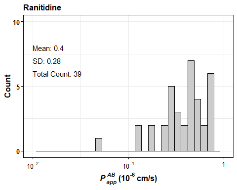

```r
  labl.dtFigRanitidinePabAdjHist <-
  caco2.perchem[casrn == "66357-35-5",.(labl = c(
    paste0("Mean: ",signif(mPab,2)),
    paste0("SD: ", signif(sdPab,2)),
   # paste0("CV: ", signif(cvPab,2)),
    paste0("Total Count: ", ntotal_ab)),
                                                   x = 0.01,
                                                   y = 0+c(8,7,6#,5
                                                           ))]
  labl.dtFigRanitidinePabUnadjHist <-
  caco2.perchem[casrn == "66357-35-5",.(labl = c(
    paste0("Mean: ",signif(mPab0,2)),
    paste0("SD: ", signif(sdPab0,2)),
  #  paste0("CV: ", signif(cvPab0,2)),
    paste0("Total Count: ", ntotal_ab)),
                                                   x = 0.01,
                                                   y = -1+c(8,7,6#,5
                                                           ))]
  labl.FigRanitidinePbaAdjHist <- caco2.perchem[casrn == "66357-35-5",.(labl = c(
    paste0("Mean: ",signif(mPba,2)),
    paste0("SD: ", signif(sdPba,2)),
    paste0("Total Count: ", ntotal_ba
                                                             )),
                                                    x = 0.1,
                                                    y = c(7,6,5))]
  labl.FigRanitidineEffluxRAdjHist <- caco2.perchem[casrn == "66357-35-5",.(labl = c(
    paste0("Mean: ",signif(mefflux,2)),
    paste0("SD: ", signif(sdefflux,2)),
    paste0("Total Count: ", ntotal_efflux
                                                             )),
                                                    x = 0.4,
                                                    y = -1+c(4,3.5,3))]
  labl.FigRanitidineFrecabHist <- caco2.perchem[casrn == "66357-35-5",.(labl = c(
    paste0("Mean: ",signif(mrec_ab,2)),
    paste0("SD: ", signif(sdrec_ab,2)),
     paste0("Total Count: ", ntotal_recab
                                                              )),
                                                     x = 1.1,
                                                     y = c(7,6,5))]
  labl.FigRanitidineFrecbaHist <- caco2.perchem[casrn == "66357-35-5",.(labl = c(
    paste0("Mean: ",signif(mrec_ba,2)),
    paste0("SD: ", signif(sdrec_ba,2)),
    paste0("Total Count: ", ntotal_recba
                                                              )),
                                                     x = 1.1,
                                                     y = c(10,8,6))]

  FigRanitidinePabAdjHist <- ggplot(caco2.publish[casrn == " 66357-35-5",])+
    geom_histogram(aes(x = Pab), fill= "grey80", color = "black")+
    geom_text(data = labl.dtFigRanitidinePabAdjHist,
              aes(x = x, y= y, label = labl), hjust = 0)+
    labs(title = "Ranitidine",
         y = expression(bold("Count")),
         x = expression(bolditalic("P"["app"]^"AB")~bold('(10'^'-6'~'cm/s)'))) +
    scale_x_log10(labels=scientific_10,limits=c(10^-2,10^0))+
    scale_y_continuous(breaks = c(0,5,10), labels = c(0,5,10), limits = c(0,10))+
    theme_bw()+
    gtheme
  print(FigRanitidinePabAdjHist)
```

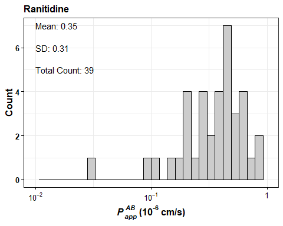

```r
  FigRanitidinePabUnadjHist <- ggplot(caco2.publish[casrn == " 66357-35-5",])+
    geom_histogram(aes(x = Pab0), fill= "grey80", color = "black")+
    geom_text(data = labl.dtFigRanitidinePabUnadjHist,
              aes(x = x, y= y, label = labl), hjust = 0)+
    labs(title = "Ranitidine",
         y = expression(bold("Count")),
         x = expression(bolditalic("P"["app"]^"AB")~bold('(10'^'-6'~'cm/s)'))) +
    scale_x_log10(labels=scientific_10,limits=c(10^-2,10^0))+
    theme_bw()+
    gtheme
  print(FigRanitidinePabUnadjHist)
```

```r
  FigRanitidinePbaAdjHist <- ggplot(caco2.publish[casrn == " 66357-35-5",])+
    geom_histogram(aes(x = Pba), fill= "grey80", color = "black")+
    geom_text(data = labl.FigRanitidinePbaAdjHist,
              aes(x = x, y= y, label = labl), hjust = 0)+
    labs(title = "Ranitidine",
         y = expression(bold("Count")),
         x = expression(bolditalic("P"["app"]^"BA")~bold('(10'^'-6'~'cm/s)'))) +
    scale_x_log10(labels=scientific_10,limits=c(10^-1,10^2))+
    theme_bw()+
    gtheme

  FigRanitidinePbaUnadjHist <- ggplot(caco2.publish[casrn == " 66357-35-5",])+
    geom_histogram(aes(x = Pba0), fill= "grey80", color = "black")+
    labs(title = "Ranitidine",
         y = expression(bold("Count")),
         x = expression(bolditalic("P"["app"]^"BA")~bold('(10'^'-6'~'cm/s)'))) +
    scale_x_log10(labels=scientific_10,limits=c(10^-1,10^2))+
    theme_bw()+
    gtheme

  FigRanitidineEffluxRAdjHist <-
    ggplot(caco2.publish[casrn == " 66357-35-5",])+
    geom_histogram(aes(x = log10(efflux.ratio)), fill= "grey80", color = "black")+
    geom_text(data = labl.FigRanitidineEffluxRAdjHist,
              aes(x = x, y= y, label = labl), hjust = 0)+
    labs(title = "Ranitidine",
         y = expression(bold("Count")),
         x = expression(bold("Efflux Ratio"))) +
    #lims(x = c(0.75,2.25))+
    scale_x_log10(labels=scientific_10)+
    theme_bw()+
    gtheme

  FigRanitidineFrecabHist <-
    ggplot(caco2.publish[casrn == " 66357-35-5",])+
    geom_histogram(aes(x = rec_ab), fill= "grey80", color = "black")+
    geom_text(data = labl.FigRanitidineFrecabHist,
              aes(x = x, y= y, label = labl), hjust = 0)+
    labs(title = "Ranitidine",
         y = expression(bold("Count")),
         x = expression(bolditalic("F")[bolditalic("rec")]^bolditalic("AB"))) +
    lims(x = c(0,2.2))+
    scale_y_continuous(breaks = c(0,5,10))+
    theme_bw()+
    gtheme

  FigRanitidineFrecbaHist  <-
    ggplot(caco2.publish[casrn == " 66357-35-5",])+
    geom_histogram(aes(x = rec_ba), fill= "grey80", color = "black")+
    geom_text(data = labl.FigRanitidineFrecbaHist,
              aes(x = x, y= y, label = labl), hjust = 0)+
    labs(title = "Ranitidine",
         y = expression(bold("Count")),
         x = expression(bolditalic("F")[bolditalic("rec")]^bolditalic("BA"))) +
    lims(x = c(0,2.2))+
    theme_bw()+
    gtheme

  FigRanitidineEffluxRUnadjHist  <- ggplot(caco2.publish[casrn == " 66357-35-5",])+
    geom_histogram(aes(x = efflux0), fill= "grey80", color = "black")+
    labs(title = "Ranitidine",
         y = expression(bold("Count")),
         x = expression(bold("Efflux Ratio"))) +
    #lims(x = c(0.75,2.25))+
    scale_x_log10(labels=scientific_10)+
    theme_bw()+
    gtheme

  ggsave(FigRanitidinePabAdjHist, file = paste0(loc.wd,
    "/results_for_paper/Fig_Ranitidine_Pab_histo.tiff"),
         height = 3, width = 3, dpi = 600, compression = "lzw")
  ggsave(FigRanitidinePbaAdjHist, file = paste0(loc.wd,
    "/results_for_paper/Fig_Ranitidine_Pba_histo.tiff"),
         height = 3, width = 3, dpi = 600, compression = "lzw")
  ggsave(FigRanitidineEffluxRAdjHist, file = paste0(loc.wd,
    "/results_for_paper/Fig_Ranitidine_efflux_histo.tiff"),
         height = 3, width = 3, dpi = 600, compression = "lzw")
  ggsave(FigRanitidineFrecabHist, file = paste0(loc.wd,
    "/results_for_paper/Fig_Ranitidine_recab_histo.tiff"),
         height = 3, width = 3, dpi = 600, compression = "lzw")
  ggsave(FigRanitidineFrecbaHist, file = paste0(loc.wd,
    "/results_for_paper/Fig_Ranitidine_recba_histo.tiff"),
         height = 3, width = 3, dpi = 600, compression = "lzw")
  ggsave(FigRanitidinePabUnadjHist, file = paste0(loc.wd,
    "/results_for_paper/Fig_Ranitidine_Pab0_histo.tiff"),
    height = 3, width = 3, dpi = 600, compression = "lzw")
  # ggsave(g4b, file = paste0(loc.wd, "/results_for_paper/Ranitidine_Pba0_histo.tiff"),
  #        height = 3, width = 3, dpi = 600, compression = "lzw")
  # ggsave(g4c, file = paste0(loc.wd, "/results_for_paper/Ranitidine_efflux0_histo.tiff"),
  #        height = 3, width = 3, dpi = 600, compression = "lzw")
```

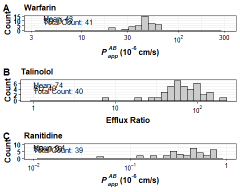

```r
ggarrange(FigWarfarinPabAdjHist, FigTalinololEffluxRAdjHist, FigRanitidinePabAdjHist,
          labels = c("A", "B", "C"),
          ncol = 1, nrow = 3,
          common.legend = TRUE, legend = "bottom")
```

```r
tiff(file = paste0(loc.wd, "/results_for_paper/Fig_RefChemsforPaper.tiff"),
         height = 5*200, width = 3*200, compression = "lzw")
ggarrange(FigWarfarinPabAdjHist, FigTalinololEffluxRAdjHist, FigRanitidinePabAdjHist,
          labels = c("A", "B", "C"),
          ncol = 1, nrow = 3,
          common.legend = TRUE, legend = "bottom"+
          theme_gray(base_size = 100))
dev.off()
```